# Table of Contents

### OpenSubtitles correlations

```
[INFO] <function Vectors.as_df at 0x128feb510> ran in 0.060 seconds
```

|  | 0 | 1 | 2 | 3 | 4 | 5 | 6 | 7 | 8 | 9 | ... | 290 | 291 | 292 | 293 | 294 | 295 | 296 | 297 | 298 | 299 |
| --- | --- | --- | --- | --- | --- | --- | --- | --- | --- | --- | --- | --- | --- | --- | --- | --- | --- | --- | --- | --- | --- |
| 0 | 0.00 | 0.04 | 0.02 | -0.00 | 0.02 | -0.03 | 0.05 | -0.01 | -0.05 | -0.00 | ... | -0.02 | -0.02 | -0.04 | 0.04 | 0.06 | 0.02 | 0.01 | -0.00 | 0.03 | -0.02 |
| 1 | 0.04 | 0.00 | -0.07 | -0.20 | 0.16 | 0.13 | -0.10 | -0.06 | 0.04 | 0.06 | ... | 0.06 | 0.01 | 0.09 | 0.09 | 0.05 | -0.00 | -0.10 | 0.07 | -0.01 | -0.09 |
| 2 | 0.02 | -0.07 | 0.00 | 0.06 | -0.13 | -0.12 | 0.04 | -0.02 | -0.08 | 0.03 | ... | -0.01 | 0.06 | -0.04 | -0.13 | -0.06 | -0.01 | 0.05 | -0.08 | -0.00 | 0.10 |
| 3 | -0.00 | -0.20 | 0.06 | 0.00 | -0.15 | -0.09 | 0.13 | 0.11 | -0.08 | -0.06 | ... | 0.03 | 0.02 | -0.10 | -0.06 | -0.01 | -0.03 | 0.03 | 0.02 | -0.03 | 0.07 |
| 4 | 0.02 | 0.16 | -0.13 | -0.15 | 0.00 | 0.17 | -0.13 | 0.00 | 0.04 | 0.09 | ... | -0.00 | -0.01 | 0.04 | 0.07 | 0.02 | -0.02 | 0.01 | 0.06 | -0.02 | -0.12 |
| ... | ... | ... | ... | ... | ... | ... | ... | ... | ... | ... | ... | ... | ... | ... | ... | ... | ... | ... | ... | ... | ... |
| 295 | 0.02 | -0.00 | -0.01 | -0.03 | -0.02 | -0.01 | -0.02 | -0.01 | -0.00 | -0.07 | ... | -0.09 | -0.02 | 0.09 | -0.02 | -0.04 | 0.00 | 0.05 | 0.02 | 0.02 | -0.06 |
| 296 | 0.01 | -0.10 | 0.05 | 0.03 | 0.01 | -0.09 | 0.04 | 0.03 | -0.04 | -0.02 | ... | -0.28 | -0.04 | -0.06 | -0.12 | -0.14 | 0.05 | 0.00 | -0.06 | 0.15 | -0.01 |
| 297 | -0.00 | 0.07 | -0.08 | 0.02 | 0.06 | 0.00 | -0.02 | 0.01 | 0.01 | 0.00 | ... | 0.05 | 0.00 | 0.01 | 0.08 | 0.04 | 0.02 | -0.06 | 0.00 | -0.03 | -0.02 |
| 298 | 0.03 | -0.01 | -0.00 | -0.03 | -0.02 | 0.02 | -0.04 | -0.02 | 0.03 | 0.01 | ... | -0.15 | -0.06 | -0.06 | -0.03 | -0.06 | 0.02 | 0.15 | -0.03 | 0.00 | -0.01 |
| 299 | -0.02 | -0.09 | 0.10 | 0.07 | -0.12 | -0.09 | 0.07 | 0.01 | -0.04 | 0.02 | ... | 0.07 | 0.02 | -0.04 | -0.08 | -0.03 | -0.06 | -0.01 | -0.02 | -0.01 | 0.00 |

300 rows × 300 columns

|  | summary |
| --- | --- |
| count | 90000.00 |
| mean | 0.00 |
| std | 0.04 |
| min | -0.28 |
| 25% | -0.03 |
| 50% | 0.00 |
| 75% | 0.03 |
| max | 0.21 |

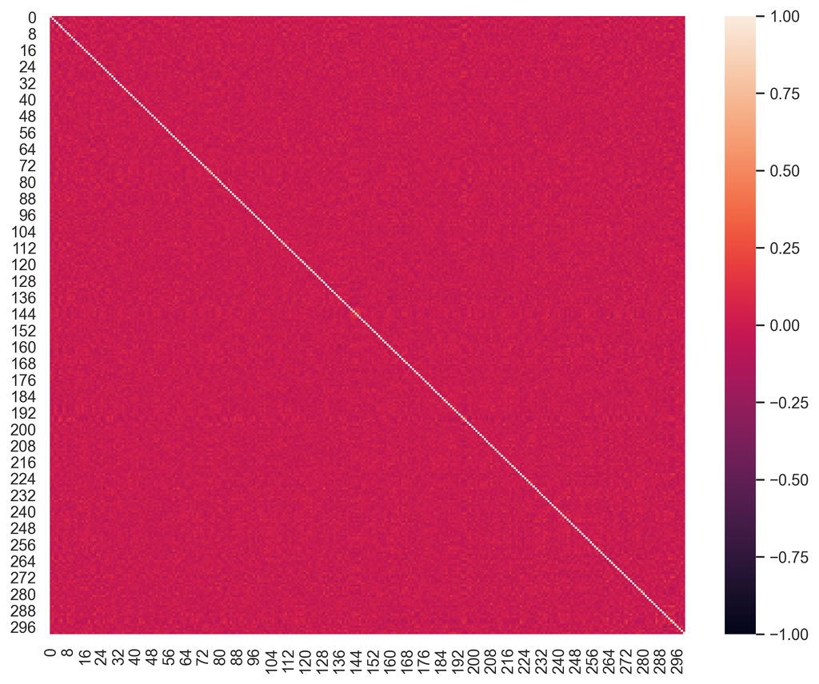

```python
subs_en_corrs, subs_en_corrs_summary, subs_en_heatmap = correlations(subs_en, d)
display(subs_en_corrs.round(2))
display(subs_en_corrs_summary.round(2))
```

# Decompositions

## Principal Components Analysis

```python
pd.set_option('display.min_rows', 20)
from common_core import pca_neighbors
```

### Common Crawl PCA

```python
cc_en_pca_nn, cc_en_pca_comp = pca_neighbors(cc_en, d)
display(cc_en_pca_nn)
```

```
[INFO] <function Vectors.as_dict at 0x128feb620> ran in 0.014 seconds
[INFO] computing analogies using whole matrix additive method
[INFO] <function compute_nn at 0x128feb9d8> ran in 0.722 seconds
[INFO] <function pca_neighbors at 0x1328e9d90> ran in 1.345 seconds
```

|  | target | neighbor 0 | neighbor 1 | neighbor 2 | neighbor 3 | neighbor 4 | neighbor -5 | neighbor -4 | neighbor -3 | neighbor -2 | neighbor -1 |
| --- | --- | --- | --- | --- | --- | --- | --- | --- | --- | --- | --- |
| 0 | 0 | Art | School | Corner | Green | International | sort | might | rather | obviously | potentially |
| 1 | 1 | Alex | Brian | Laura | Renee | Michael | Database | applications | Integration | Application | Structure |
| 2 | 2 | Regarding | Understanding | Specifically | Consider | Given | pineapple | peach | wooden | wood | strawberry |
| 3 | 3 | Just | LOL | Ok | Yep | lol | district | institutions | authorities | establishment | government |
| 4 | 4 | 136 | 130 | 113 | 115 | 135 | obsession | beauty | passion | love | Love |
| 5 | 5 | remained | swept | midst | glorious | dominated | e-mail | docs | pal | email | advisor |
| 6 | 6 | utilizes | incorporates | configuration | supplied | incorporating | Muslim | atheists | Muslims | people | Christians |
| 7 | 7 | invited | visit | visiting | shop | visited | physiological | degradation | sensitivity | complexity | distortion |
| 8 | 8 | delightful | eclectic | exquisite | unique | colorful | halt | withdraw | shut | threaten | causing |
| 9 | 9 | announcement | poster | declaration | publication | screenshot | those | Many | areas | many | individuals |
| ... | ... | ... | ... | ... | ... | ... | ... | ... | ... | ... | ... |
| 290 | 290 | index.php | en.wikipedia.org | Revitol | Logged | Aires | F.2d | Cir | goals2 | goals1 | les |
| 291 | 291 | reviewsSave | PostReport | 'T | establishments | ¯ | importantly | showthread.php | goals2 | votecounter.cgi | TypeEntire |
| 292 | 292 | PRODed | AfDed | SPAMInappropriate | LINEAR | Gmina | TypeEntire | prev | votecounter.cgi | F.2d | Gene93k |
| 293 | 293 | votecounter.cgi | UserReport | Niches | TypeEntire | S.Ct. | figures.Send | reviewsSave | aptProperty | roomProperty | viewfull |
| 294 | 294 | U- | Males | overlap | ROOT | ) | jackbot | EmailView | UserReport | ✖ | F.2d |
| 295 | 295 | TypePrivate | roomProperty | kr | PUBLISHED | las | 'T | ↵ | cur | figures.Send | S.Ct. |
| 296 | 296 | UserReport | v. | yearPlease |  | WP | dans | une | Wikia | EmailView | F.2d |
| 297 | 297 | Aviv | Filed | yd | notably | Whereas | overlaps | prev | Hong | kr | U- |
| 298 | 298 | votecounter.cgi | UserReport | clubnat | ↵ | Spacewatch | ⋅ | Dame | Enhancement | et | sentenced |
| 299 | 299 | tools.wmflabs.org | Imports | 'T | Puerto | https | Rs | SK | WP | Preceding | Transaction |

300 rows × 11 columns

### OpenSubtitles PCA

```python
subs_en_pca_nn, subs_en_pca_comp = pca_neighbors(subs_en, d)
display(subs_en_pca_nn)
```

```
[INFO] <function Vectors.as_dict at 0x128feb620> ran in 0.012 seconds
[INFO] computing analogies using whole matrix additive method
[INFO] <function compute_nn at 0x128feb9d8> ran in 0.667 seconds
[INFO] <function pca_neighbors at 0x1328e9d90> ran in 1.222 seconds
```

|  | target | neighbor 0 | neighbor 1 | neighbor 2 | neighbor 3 | neighbor 4 | neighbor -5 | neighbor -4 | neighbor -3 | neighbor -2 | neighbor -1 |
| --- | --- | --- | --- | --- | --- | --- | --- | --- | --- | --- | --- |
| 0 | 0 | Jess | Maggie | Katie | Beth | Sadie | characteristics | institutions | regions | widespread | structures |
| 1 | 1 | noodle | buns | seaweed | marshmallows | dripping | administration | Rand | District_Attorney | formally | Attorney_General |
| 2 | 2 | AND | WHAT_ABOUT | WITH | FOR_THE | ON_THAT | jealous | selfish | affectionate | shameless | indifferent |
| 3 | 3 | AND | ALL_THE_TIME | LOVE_YOU | OUT_THERE | THAT | generators | storage | components | panels | containers |
| 4 | 4 | overreacting | freaking_out | stressed_out | freaked_out | hallucinating | Tsar | Spain | Spaniards | princes | peasants |
| 5 | 5 | arrested | jailed | bribed | detained | deported | creatures | vibration | human_brain | evolution | humankind |
| 6 | 6 | universities | celebrities | restaurants | actresses | colleges | retrieved | Release | ambushed | nearly_killed | attacked |
| 7 | 7 | Growing_up | dominated | battling | most_popular | featured | sedative | Your_Excellency | detonator | bandage | Excellency |
| 8 | 8 | scumbags | drug_dealers | crooks | criminals | motherfuckers | wedding_present | marvellous | recital | lovely | exquisite |
| 9 | 9 | Appreciate | Excellent | Practice | Ready | Personal | butchered | tortured | drugged | fled | persecuted |
| ... | ... | ... | ... | ... | ... | ... | ... | ... | ... | ... | ... |
| 290 | 290 | how | has | why | as | Has | Noit | lt | This | It | That |
| 291 | 291 | of | Of | o_f | in | οf | A_NEW | The | AN | an | An |
| 292 | 292 | in | of | the | this | In | Does | makes | Were | They | We |
| 293 | 293 | your | my | his | their | Whose | Weve | Youve | ve | we | have |
| 294 | 294 | m | am | re | he | she | him | Into | Has | into | me |
| 295 | 295 | a | A | any | Another | ofa | where | How | how | an | An |
| 296 | 296 | my | an | your | his | An | tο | from | a | A | to |
| 297 | 297 | in | we | on | into | I | EVERY | knowwhat | What | what | how |
| 298 | 298 | will | are | should | were | shall | You | his | We | my | your |
| 299 | 299 | </s> | and | that | now | you | SIGHS | Τhe | y0u | His_name | t0 |

300 rows × 11 columns

## Independent Component Analysis

```python
from common_core import ica_neighbors
```

### Common Crawl ICA

```python
cc_en_ica_nn, cc_en_ica_comp = ica_neighbors(cc_en, d)
display(cc_en_ica_nn)
```

```
[INFO] <function Vectors.as_dict at 0x128feb620> ran in 0.017 seconds
[INFO] computing analogies using whole matrix additive method
[INFO] <function compute_nn at 0x128feb9d8> ran in 0.688 seconds
[INFO] <function ica_neighbors at 0x136751bf8> ran in 46.280 seconds
```

|  | target | neighbor 0 | neighbor 1 | neighbor 2 | neighbor 3 | neighbor 4 | neighbor -5 | neighbor -4 | neighbor -3 | neighbor -2 | neighbor -1 |
| --- | --- | --- | --- | --- | --- | --- | --- | --- | --- | --- | --- |
| 0 | 0 | tenor | soap | chassis | bronze | fixtures | downloading | iTunes | download | mp3 | MP3 |
| 1 | 1 | HIDDEN | serves | peacefully | Alternative | for | thrilled | shocked | surprised | intrigued | excited |
| 2 | 2 | Carnegie | las | Says | eclipse | Opera | VIII | III | IV | VI | VII |
| 3 | 3 | Oral | accept | insist | owns | approximations | intended | attract | empower | geared | aimed |
| 4 | 4 | S.Ct. | Parade | stripped | parade | Scotia | relationships | alliance | mutual | friendship | relationship |
| 5 | 5 | chronology | Mirror | tournaments | harvest | PGA | pet | cat | dogs | puppy | dog |
| 6 | 6 | smashed | knocked | knocking | smash | knock | disappearance | Permanent | Spot | Silent | silent |
| 7 | 7 | southeastern | northeastern | northern | southern | southwestern | approximations | ् | Reputation | 'S | Username |
| 8 | 8 | Roosevelt | app | Alfred | Nazi | Einstein | 2001 | 1998 | 1996 | 1997 | 1999 |
| 9 | 9 | Continuing | versa | ignition | Outstanding | Announces | Corn | Red | Yellow | Sand | Blue |
| ... | ... | ... | ... | ... | ... | ... | ... | ... | ... | ... | ... |
| 290 | 290 | Europeans | Asians | ancestry | immigrants | ethnic | HP | Potter | frac | sector | Ministry |
| 291 | 291 | Merry | supermarket | Walmart | Starbucks | Score | conferences | seminars | conference | keynote | seminar |
| 292 | 292 | Oak | weave | Flint | weaving | Mighty | capitalist | capitalism | socialist | socialism | ideology |
| 293 | 293 | building | tower | construction | buildings | demolition | blunt | disposable | diluted | Suzuki | throttle |
| 294 | 294 | Cir | cohort | Edited | group | spokeswoman | accomplishments | improvements | enhancements | successes | activities |
| 295 | 295 | reasons | option | choice | reason | Reasons | deadlines | Somehow | exceeded | exceed | surpassed |
| 296 | 296 | increased | dramatically | greatly | drastically | enhanced | adequately | alike | perfectly | Mt | exactly |
| 297 | 297 | lump | ้ | granite | ago | overwhelming | safety | durability | stability | fairness | integrity |
| 298 | 298 | Edison | Pan | PRODed | Prefecture | 'an | WITH | JUST | FOR | THIS | THE |
| 299 | 299 | Resorts | psychologist | chips | SSD | Intel | renal | cardiac | coronary | vascular | artery |

300 rows × 11 columns

### OpenSubtitles ICA

```python
subs_en_ica_nn, subs_en_ica_comp = ica_neighbors(subs_en, d)
display(subs_en_ica_nn)
```

```
[INFO] <function Vectors.as_dict at 0x128feb620> ran in 0.019 seconds
[INFO] computing analogies using whole matrix additive method
[INFO] <function compute_nn at 0x128feb9d8> ran in 0.711 seconds
[INFO] <function ica_neighbors at 0x136751bf8> ran in 47.782 seconds
```

|  | target | neighbor 0 | neighbor 1 | neighbor 2 | neighbor 3 | neighbor 4 | neighbor -5 | neighbor -4 | neighbor -3 | neighbor -2 | neighbor -1 |
| --- | --- | --- | --- | --- | --- | --- | --- | --- | --- | --- | --- |
| 0 | 0 | come | coming | bring | came | bringing | Shake | disarm | rot | Kip | GUY |
| 1 | 1 | Keeps | these_days | Message | glued | collect | underway | ended | finish | finished | completed |
| 2 | 2 | stickers | THOSE | outdated | sway | idiotic | scientist | technician | journalist | writer | musician |
| 3 | 3 | rules | regulations | laws | regulation | Rules | Bambi | sidekick | savior | self_esteem | Goku |
| 4 | 4 | strike | by_lightning | Enrique | struck | signs | boundaries | stretched | beyond | limit | limits |
| 5 | 5 | executive | melting | Centre | Jazz | supreme | sheep | cows | cattle | horses | horse |
| 6 | 6 | Check | Checking | check | checking | hung | apart | Vaughn | Damien | face | with |
| 7 | 7 | million_dollar | decade | Fi | million_dollars | icon | 16 | 19 | 13 | 23 | 14 |
| 8 | 8 | whereas | ALL | Otherwise | or | Unless | few_days_ago | year_ago | months_ago | few_months_ago | few_years_ago |
| 9 | 9 | miles | dollars | pounds | inches | metres | WE_LL | 12th | Lo | two | three |
| ... | ... | ... | ... | ... | ... | ... | ... | ... | ... | ... | ... |
| 290 | 290 | lot_easier | hardest_thing | natural | HUH | new_era | each | every_single | Every_single | Every | every |
| 291 | 291 | OF_THE | Soft | ITS | OFF | supportive | Sir | ma_am | Colonel | Mr | sir |
| 292 | 292 | yet | t0 | full | even | technically | Dixie | Adams | Robin | Lily | Western |
| 293 | 293 | hardly | urgently | seemingly | 16_year_old | 20_year_old | gonna | ready | strong_enough | supposed | going |
| 294 | 294 | he | She | He | SHALL | she | journalists | men | businessmen | people | musicians |
| 295 | 295 | Finished | Safe | hesitation | big_mistake | How_bout | sell | conquer | steal | kill | seduce |
| 296 | 296 | song | guitar | band | songs | piano | Jen | Granger | Grunts | Luthor | Talbot |
| 297 | 297 | bowels | clause | blink | celebrities | flush | blood_sample | sample | samples | DNA_test | analysis |
| 298 | 298 | dusty | Dallas | Central | Denver | Munich | shore | sail | sailing | boats | boat |
| 299 | 299 | Hermann | Hans | Heinrich | Reich | Karl | Jimmy | vice_president | Jane | Ivy | Ruby |

300 rows × 11 columns

## Factor Analysis

```python
from common_core import fa_neighbors
```

### Common Crawl FA

```python
cc_en_fa_nn, cc_en_fa_comp = fa_neighbors(cc_en, d)
display(cc_en_fa_nn)
```

```
[INFO] <function Vectors.as_dict at 0x128feb620> ran in 0.009 seconds
[INFO] computing analogies using whole matrix additive method
[INFO] <function compute_nn at 0x128feb9d8> ran in 0.723 seconds
[INFO] <function fa_neighbors at 0x1328e9ea0> ran in 1.623 seconds
```

|  | target | neighbor 0 | neighbor 1 | neighbor 2 | neighbor 3 | neighbor 4 | neighbor -5 | neighbor -4 | neighbor -3 | neighbor -2 | neighbor -1 |
| --- | --- | --- | --- | --- | --- | --- | --- | --- | --- | --- | --- |
| 0 | 0 | Art | School | Jr | Studio | International | sort | certain | obviously | potentially | might |
| 1 | 1 | Alex | Laura | Brian | Renee | Carolyn | Database | Application | Methods | Integration | Structure |
| 2 | 2 | wood | wooden | plastic | satin | strawberry | Given | regarding | consider | Understanding | Regarding |
| 3 | 3 | government | citizens | institutions | authorities | leaders | Insert | Pull | Can | Check | Just |
| 4 | 4 | love | mommy | Mommy | Love | lover | 115 | 133 | 113 | 130 | 136 |
| 5 | 5 | midst | Valley | northern | Island | northwest | u | PS | i | Hi | ï |
| 6 | 6 | people | People | Americans | Most | foreigners | Richard | incorporates | Allison | Reynolds | Gregory |
| 7 | 7 | ignorance | irrational | societal | psychological | systemic | shipped | sent | store | purchased | shop |
| 8 | 8 | delay | withdraw | resign | halt | stop | charming | colorful | beautiful | wonderfully | unique |
| 9 | 9 | types | kinds | those | areas | Many | interview | blog | masterpiece | inaugural | official |
| ... | ... | ... | ... | ... | ... | ... | ... | ... | ... | ... | ... |
| 290 | 290 | viagra | > | -- | etc | echo | s | ’ | � | “ | ” |
| 291 | 291 | Direction | Basket | Arena |  | par | ReportHelpful | Ctrip | Q | Puerto | du |
| 292 | 292 | Present | Tutors | AfDView | Ariana | goals2 | PostReport | Luther | SPAMInappropriate | pagename | Laden |
| 293 | 293 | refunds | odds | structural | Dragon | funeral | locker | quirky | Pune | BlackBerry | , |
| 294 | 294 | refunds | odds | structural | Dragon | funeral | locker | quirky | Pune | BlackBerry | , |
| 295 | 295 | refunds | odds | structural | Dragon | funeral | locker | quirky | Pune | BlackBerry | , |
| 296 | 296 | refunds | odds | structural | Dragon | funeral | locker | quirky | Pune | BlackBerry | , |
| 297 | 297 | refunds | odds | structural | Dragon | funeral | locker | quirky | Pune | BlackBerry | , |
| 298 | 298 | refunds | odds | structural | Dragon | funeral | locker | quirky | Pune | BlackBerry | , |
| 299 | 299 | refunds | odds | structural | Dragon | funeral | locker | quirky | Pune | BlackBerry | , |

300 rows × 11 columns

### OpenSubtitles FA

```python
subs_en_fa_nn, subs_en_fa_comp = fa_neighbors(subs_en, d)
display(subs_en_fa_nn)
```

```
[INFO] <function Vectors.as_dict at 0x128feb620> ran in 0.011 seconds
[INFO] computing analogies using whole matrix additive method
[INFO] <function compute_nn at 0x128feb9d8> ran in 0.664 seconds
[INFO] <function fa_neighbors at 0x1328e9ea0> ran in 1.583 seconds
```

|  | target | neighbor 0 | neighbor 1 | neighbor 2 | neighbor 3 | neighbor 4 | neighbor -5 | neighbor -4 | neighbor -3 | neighbor -2 | neighbor -1 |
| --- | --- | --- | --- | --- | --- | --- | --- | --- | --- | --- | --- |
| 0 | 0 | Jess | Maggie | Katie | Beth | Sadie | institutions | governments | regions | widespread | structures |
| 1 | 1 | Elizabeth | Attorney_General | administration | formally | Patricia | cans | seaweed | buns | noodle | hissing |
| 2 | 2 | WHAT_ABOUT | AND | US | OFFICER | TO_THE | feel_ashamed | jealous | selfish | teasing | shameless |
| 3 | 3 | AND | OUT_THERE | LOVE_YOU | ALL_THE_TIME | THAT | storage | container | components | panels | containers |
| 4 | 4 | overreacting | affecting | side_effect | interaction | freaking_out | beggars | Spain | provinces | merchants | peasants |
| 5 | 5 | humankind | Nature | creatures | mankind | Humans | assaulted | detained | interrogated | harassing | arrested |
| 6 | 6 | restaurants | dinners | universities | colleges | celebrities | unharmed | nearly_killed | Surrender | Release | attacked |
| 7 | 7 | Excellency | bandage | handkerchief | Your_Excellency | notary | awesome | most_popular | battling | dominated | Growing_up |
| 8 | 8 | scumbags | drug_dealers | criminals | crooks | gangsters | Dearest | marvellous | recital | lovely | exquisite |
| 9 | 9 | fled | strangled | drugged | killed_herself | tortured | Personal | Training | Support | Management | Appreciate |
| ... | ... | ... | ... | ... | ... | ... | ... | ... | ... | ... | ... |
| 290 | 290 | in | into | ln | In | i_n | upon | have | has | On | on |
| 291 | 291 | are | were | re | of | be | might | Would | Might | an | An |
| 292 | 292 | pastries | blues | Lance | costumes | rushing | Sad | est | posh | unfaithful | </s> |
| 293 | 293 | pastries | blues | Lance | costumes | rushing | Sad | est | posh | unfaithful | </s> |
| 294 | 294 | pastries | blues | Lance | costumes | rushing | Sad | est | posh | unfaithful | </s> |
| 295 | 295 | pastries | blues | Lance | costumes | rushing | Sad | est | posh | unfaithful | </s> |
| 296 | 296 | pastries | blues | Lance | costumes | rushing | Sad | est | posh | unfaithful | </s> |
| 297 | 297 | pastries | blues | Lance | costumes | rushing | Sad | est | posh | unfaithful | </s> |
| 298 | 298 | pastries | blues | Lance | costumes | rushing | Sad | est | posh | unfaithful | </s> |
| 299 | 299 | pastries | blues | Lance | costumes | rushing | Sad | est | posh | unfaithful | </s> |

300 rows × 11 columns

## Rotated FA solutions

### Varimax rotated Common Crawl FA

```python
cc_en_fa_nn, cc_en_fa_comp = fa_neighbors(cc_en, d, rotation='varimax')
display(cc_en_fa_nn)
```

```
[INFO] <function Vectors.as_dict at 0x128feb620> ran in 0.017 seconds
[INFO] computing analogies using whole matrix additive method
[INFO] <function compute_nn at 0x128feb9d8> ran in 1.000 seconds
[INFO] <function fa_neighbors at 0x1328e9ea0> ran in 34.455 seconds
```

|  | target | neighbor 0 | neighbor 1 | neighbor 2 | neighbor 3 | neighbor 4 | neighbor -5 | neighbor -4 | neighbor -3 | neighbor -2 | neighbor -1 |
| --- | --- | --- | --- | --- | --- | --- | --- | --- | --- | --- | --- |
| 0 | 0 | Hollow | Hunt | Lane | Creek | Flower | cultural | social | aspects | educational | provide |
| 1 | 1 | Michael | Andrew | Robert | Richard | Mike | literary | cultural | political | industrial | thermal |
| 2 | 2 | soldiers | nine | seven | women | civilians | clarify | add | explanation | excuse | suggestion |
| 3 | 3 | Bennett | Edwards | Cunningham | Clarke | Robinson | definately | thats | ok | wont | lol |
| 4 | 4 | Bennett | Boyd | Edwards | Riley | Miller | 9 | 6 | 17 | 7 | : |
| 5 | 5 | existence | midst | turmoil | ongoing | enduring | send | hats | pulls | stickers | inserts |
| 6 | 6 | people | those | many | know | there | Integrated | Toggle | COIBot | Enhanced | Detailed |
| 7 | 7 | acknowledging | ignoring | misunderstanding | questioning | avoiding | Schools | Programs | Showcase | Center | Program |
| 8 | 8 | lowering | falling | Lower | reducing | lower | wonderful | books | many | Several | couple |
| 9 | 9 | institutions | types | agencies | factors | kinds | fourth | duck | a | first | second |
| ... | ... | ... | ... | ... | ... | ... | ... | ... | ... | ... | ... |
| 290 | 290 | An | Throughout | an | AfDView | on | Bowl | Hill | Tree | Ridge | </s> |
| 291 | 291 | from | throughout | lending | separating | spite | Distribution | Description | Biggest | A | ShortSummary |
| 292 | 292 | Kitt | Non-Member | Guides | Teachers | Association | seemingly | Notre | Palo | cubic | Las |
| 293 | 293 | refunds | odds | structural | Dragon | funeral | locker | quirky | Pune | BlackBerry | , |
| 294 | 294 | refunds | odds | structural | Dragon | funeral | locker | quirky | Pune | BlackBerry | , |
| 295 | 295 | refunds | odds | structural | Dragon | funeral | locker | quirky | Pune | BlackBerry | , |
| 296 | 296 | refunds | odds | structural | Dragon | funeral | locker | quirky | Pune | BlackBerry | , |
| 297 | 297 | refunds | odds | structural | Dragon | funeral | locker | quirky | Pune | BlackBerry | , |
| 298 | 298 | refunds | odds | structural | Dragon | funeral | locker | quirky | Pune | BlackBerry | , |
| 299 | 299 | refunds | odds | structural | Dragon | funeral | locker | quirky | Pune | BlackBerry | , |

300 rows × 11 columns

### Quartimax rotated Common Crawl FA

```python
cc_en_fa_nn, cc_en_fa_comp = fa_neighbors(cc_en, d, rotation='quartimax')
display(cc_en_fa_nn)
```

```
[INFO] <function Vectors.as_dict at 0x128feb620> ran in 0.015 seconds
[INFO] computing analogies using whole matrix additive method
[INFO] <function compute_nn at 0x128feb9d8> ran in 0.818 seconds
[INFO] <function fa_neighbors at 0x1328e9ea0> ran in 30.544 seconds
```

|  | target | neighbor 0 | neighbor 1 | neighbor 2 | neighbor 3 | neighbor 4 | neighbor -5 | neighbor -4 | neighbor -3 | neighbor -2 | neighbor -1 |
| --- | --- | --- | --- | --- | --- | --- | --- | --- | --- | --- | --- |
| 0 | 0 | Hollow | Hunt | Lane | Creek | Flower | cultural | aspects | social | educational | provide |
| 1 | 1 | Michael | Robert | Andrew | Richard | Mike | literary | cultural | political | thermal | industrial |
| 2 | 2 | soldiers | nine | seven | women | civilians | add | clarify | explanation | excuse | suggestion |
| 3 | 3 | Bennett | Cunningham | Edwards | Clarke | Barker | thats | definately | ok | wont | lol |
| 4 | 4 | Bennett | Boyd | Edwards | Miller | Riley | 4 | 5 | 17 | 6 | 7 |
| 5 | 5 | existence | midst | enduring | turmoil | ongoing | pulls | clips | hats | stickers | inserts |
| 6 | 6 | those | people | many | know | there | Integrated | Enhanced | Toggle | Detailed | COIBot |
| 7 | 7 | acknowledging | ignoring | misunderstanding | questioning | accusing | Projects | Programs | Center | Showcase | Program |
| 8 | 8 | lowering | falling | Lower | sliding | reducing | Several | many | handful | dozen | couple |
| 9 | 9 | institutions | types | kinds | agencies | aspects | comeback | duck | first | a | second |
| ... | ... | ... | ... | ... | ... | ... | ... | ... | ... | ... | ... |
| 290 | 290 | helmets | helmet | styling | chrome | ain | assigned | scheduled | announced | recruited | confirmed |
| 291 | 291 | red | yellow | blue | white | purple | continuing | facilitate | partnering | assisting | establishing |
| 292 | 292 | 12 | Hi | pm | writes | 13 | Integrated | associated | evidenced | integrating | toward |
| 293 | 293 | refunds | odds | structural | Dragon | funeral | locker | quirky | Pune | BlackBerry | , |
| 294 | 294 | refunds | odds | structural | Dragon | funeral | locker | quirky | Pune | BlackBerry | , |
| 295 | 295 | refunds | odds | structural | Dragon | funeral | locker | quirky | Pune | BlackBerry | , |
| 296 | 296 | refunds | odds | structural | Dragon | funeral | locker | quirky | Pune | BlackBerry | , |
| 297 | 297 | refunds | odds | structural | Dragon | funeral | locker | quirky | Pune | BlackBerry | , |
| 298 | 298 | refunds | odds | structural | Dragon | funeral | locker | quirky | Pune | BlackBerry | , |
| 299 | 299 | refunds | odds | structural | Dragon | funeral | locker | quirky | Pune | BlackBerry | , |

300 rows × 11 columns

### Oblimin rotated Common Crawl FA

```python
cc_en_fa_nn, cc_en_fa_comp = fa_neighbors(cc_en, d, rotation='oblimin', rotate_args=[1, 'oblique'])
display(cc_en_fa_nn)
```

```
[INFO] <function Vectors.as_dict at 0x128feb620> ran in 0.023 seconds
[INFO] computing analogies using whole matrix additive method
[INFO] <function compute_nn at 0x128feb9d8> ran in 1.139 seconds
[INFO] <function fa_neighbors at 0x1328e9ea0> ran in 15.968 seconds
```

|  | target | neighbor 0 | neighbor 1 | neighbor 2 | neighbor 3 | neighbor 4 | neighbor -5 | neighbor -4 | neighbor -3 | neighbor -2 | neighbor -1 |
| --- | --- | --- | --- | --- | --- | --- | --- | --- | --- | --- | --- |
| 0 | 0 | Update | Event | Official | Trailer | Destination | intensely | enriched | sustain | naturally | delicate |
| 1 | 1 | tonight | dinner | him | girlfriend | night | systems | components | methods | Methods | processes |
| 2 | 2 | cardboard | plastic | antique | cans | tin | pivotal | leadership | Leadership | decisive | Leaders |
| 3 | 3 | mandated | committed | commitments | obligations | leaders | tube | picture | cube | clip | pic |
| 4 | 4 | pic | cute | gorgeous | doll | lovely | Evaluation | Assessment | implementation | Effective | Administrative |
| 5 | 5 | fortunate | truly | deserved | endure | endured | Products | Data | Miscellaneous | Catalog | Database |
| 6 | 6 | town | residents | bankrupt | rented | families | geometry | Interface | diagram | interface | visualization |
| 7 | 7 | subtle | articulate | dynamic | understanding | insight | groceries | farms | rent | rented | leased |
| 8 | 8 | residents | citizens | eligible | pledged | attend | textured | geometric | geometry | clip | texture |
| 9 | 9 | Methods | Evaluation | Assessment | Specific | Data | gorgeous | beautiful | delightful | loved | lovely |
| ... | ... | ... | ... | ... | ... | ... | ... | ... | ... | ... | ... |
| 290 | 290 | processes | methods | structures | components | forms | Bobby | Mike | Frankie | tonight | Kenny |
| 291 | 291 | Data | Documents | Database | Assessment | Analysis | joyful | delightful | beautiful | delicious | delight |
| 292 | 292 | Update | Reference | Data | Topic | Database | delicate | embrace | naturally | endure | sustain |
| 293 | 293 | refunds | odds | structural | Dragon | funeral | locker | quirky | Pune | BlackBerry | , |
| 294 | 294 | refunds | odds | structural | Dragon | funeral | locker | quirky | Pune | BlackBerry | , |
| 295 | 295 | refunds | odds | structural | Dragon | funeral | locker | quirky | Pune | BlackBerry | , |
| 296 | 296 | refunds | odds | structural | Dragon | funeral | locker | quirky | Pune | BlackBerry | , |
| 297 | 297 | refunds | odds | structural | Dragon | funeral | locker | quirky | Pune | BlackBerry | , |
| 298 | 298 | refunds | odds | structural | Dragon | funeral | locker | quirky | Pune | BlackBerry | , |
| 299 | 299 | refunds | odds | structural | Dragon | funeral | locker | quirky | Pune | BlackBerry | , |

300 rows × 11 columns

### Quartimin rotated Common Crawl FA

```python
cc_en_fa_nn, cc_en_fa_comp = fa_neighbors(cc_en, d, rotation='oblimin', rotate_args=[0, 'oblique'])
display(cc_en_fa_nn)
```

```
[INFO] <function Vectors.as_dict at 0x128feb620> ran in 0.016 seconds
[INFO] computing analogies using whole matrix additive method
[INFO] <function compute_nn at 0x128feb9d8> ran in 0.957 seconds
[INFO] <function fa_neighbors at 0x1328e9ea0> ran in 10.919 seconds
```

|  | target | neighbor 0 | neighbor 1 | neighbor 2 | neighbor 3 | neighbor 4 | neighbor -5 | neighbor -4 | neighbor -3 | neighbor -2 | neighbor -1 |
| --- | --- | --- | --- | --- | --- | --- | --- | --- | --- | --- | --- |
| 0 | 0 | Hi | Tagged | ShortSummary | Abstract | pm | ensure | make | allow | </s> | ultimately |
| 1 | 1 | P. | A. | G. | H. | R. | affairs | governance | political | thermal | industrial |
| 2 | 2 | membrane | kinase | chloride | roller | neural | understood | interested | wished | advice | informed |
| 3 | 3 | Bennett | Barker | Cunningham | Robinson | Edwards | thats | Ive | ok | lol | ive |
| 4 | 4 | Investments | Inc. | Consulting | Industries | Publications | 25 | 15 | 10 | 30 | 20 |
| 5 | 5 | importance | situation | ongoing | existence | ViolationRe | punches | coats | inserts | stickers | hats |
| 6 | 6 | those | many | people | Many | know | revised | Enhanced | Detailed | Toggle | COIBot |
| 7 | 7 | atheists | atheist | beings | implying | ignorant | Stores | Restaurant | Bank | Company | headquarters |
| 8 | 8 | bail | coalition | hurting | shutdown | re-election | delightful | artistic | imaginative | aesthetic | eclectic |
| 9 | 9 | kinds | types | sorts | agencies | factors | Second | 's | first | a | second |
| ... | ... | ... | ... | ... | ... | ... | ... | ... | ... | ... | ... |
| 290 | 290 | fancy | hey | suppose | decorations | decoration | Biggest | Total | Maximum | Capacity | Announces |
| 291 | 291 | dig | Lets | see | Expect | invite | humanitarian | telecommunications | pharmaceutical | practiced | Thai |
| 292 | 292 | handful | adventurers | inhabited | multitude | unnamed | Safety | Communication | Training | Impact | Performance |
| 293 | 293 | refunds | odds | structural | Dragon | funeral | locker | quirky | Pune | BlackBerry | , |
| 294 | 294 | refunds | odds | structural | Dragon | funeral | locker | quirky | Pune | BlackBerry | , |
| 295 | 295 | refunds | odds | structural | Dragon | funeral | locker | quirky | Pune | BlackBerry | , |
| 296 | 296 | refunds | odds | structural | Dragon | funeral | locker | quirky | Pune | BlackBerry | , |
| 297 | 297 | refunds | odds | structural | Dragon | funeral | locker | quirky | Pune | BlackBerry | , |
| 298 | 298 | refunds | odds | structural | Dragon | funeral | locker | quirky | Pune | BlackBerry | , |
| 299 | 299 | refunds | odds | structural | Dragon | funeral | locker | quirky | Pune | BlackBerry | , |

300 rows × 11 columns

# Interim takeaways

1. Embedding dimensions are largely uncorrelated/orthogonal, with the caveat that embeddings trained with BOW specifically seem to have have clumps of more correlated dimensions. (Section 2.1)
2. The first few components/factors in PCA and FA solutions seem to be quite similar, which is generally true for data with a large number of variables (see e.g. [this CrossValidated answer](https://stats.stackexchange.com/a/123136)). (Section 3)
3. The last 7 factors in the FA solution appear identical, whereas the last 7 components of the PCA solution appear nonsensical, but unique. This is a consequence of the difference in the PCA and FA algorithms: PCA decomposes all the variance in the data into orthogonal components, starting with the component that explains the most variance and ending with the component that explains the least variance; all variance must be apportioned, meaning that as long as there are no collinear dimensions in the data, there will be as many components in the PCA solution as there are dimensions in the original dataset. FA on the other hand identifies latent factors based on correlations between variables/dimensions in the data; there are generally a lot fewer latent factors than dimensions in a dataset. (Section 3)
4. Many of the PCA and FA components seem to capture some kind of coherent conceptual-semantic dimension, judging by the semantic similarity in the clusters of words at the extreme ends of the component. However, many of the contrasts (between the two ends of a component) do not seem to fall along the same dimensions as conventional lexical norms. (Section 3)
5. Rotating the FA solutions using Varimax or Quartimax rotation seems to have a broadly similar effect.

# Filtering using a dictionary

```python
# TODO: implement a dictionary for filtering (maybe find a dictionary better than the AoA word list?)
```

# Filtering for Age of Acquisition

## AoA dataset

To filter for age of acquisition, we can use the Kuperman et al. (2012) norms for English.

```python
# filter datasets
df_aoa_en = pd.read_csv('en-kuperman-2012.tsv', sep='\t', comment='#')  # load data
df_aoa_en = df_aoa_en[df_aoa_en['age of acquisition'] < 6].sort_values('age of acquisition')
display(df_aoa_en)
```

|  | word | age of acquisition |
| --- | --- | --- |
| 17429 | momma | 1.58 |
| 16407 | mama | 1.89 |
| 2069 | bantling | 2.00 |
| 17424 | mom | 2.22 |
| 20924 | potty | 2.28 |
| 31031 | yes | 2.31 |
| 30336 | water | 2.37 |
| 19001 | ouch | 2.42 |
| 30483 | wet | 2.47 |
| 25738 | spoon | 2.50 |
| ... | ... | ... |
| 23034 | restaurant | 5.95 |
| 26051 | stereo | 5.95 |
| 11493 | germ | 5.95 |
| 6461 | crust | 5.95 |
| 4529 | chickenpox | 5.95 |
| 20308 | pigpen | 5.95 |
| 1462 | arts | 5.97 |
| 27531 | thorn | 5.97 |
| 1925 | backwards | 5.98 |
| 2375 | being | 5.99 |

1985 rows × 2 columns

That the word "bantling" is judged as having an AoA of 2.00 is telling: It's British-English for infant, but it's dialect and not likely a word that an actual two-year old would know. (Seems possible that there was only one rater that knew the word, and they associated it with infants, rather than properly judging whether an infant would know the word.)

Regardless, we have approximately 2000 low-AoA words (with some noise) which we can use to filter word vectors.

```python
from common_core import filter_vecs
aoa_cc_en = filter_vecs(cc_en, df_aoa_en['word'])
aoa_subs_en = filter_vecs(subs_en, df_aoa_en['word'])
```

Filtered 20000 vectors, 1465 remaining.

```
[INFO] <function filter_vecs at 0x1328ec048> ran in 2.910 seconds
```

Filtered 20000 vectors, 1630 remaining.

```
[INFO] <function filter_vecs at 0x1328ec048> ran in 1.631 seconds
```

## AoA-filtered PCA

### AoA-filtered Common Crawl PCA

```python
aoa_cc_en_pca_nn, aoa_cc_en_pca_comp = pca_neighbors(aoa_cc_en, d)
display(aoa_cc_en_pca_nn)
```

```
[INFO] <function Vectors.as_dict at 0x128feb620> ran in 0.001 seconds
[INFO] computing analogies using whole matrix additive method
[INFO] <function compute_nn at 0x128feb9d8> ran in 0.042 seconds
[INFO] <function pca_neighbors at 0x1328e9d90> ran in 0.108 seconds
```

|  | target | neighbor 0 | neighbor 1 | neighbor 2 | neighbor 3 | neighbor 4 | neighbor -5 | neighbor -4 | neighbor -3 | neighbor -2 | neighbor -1 |
| --- | --- | --- | --- | --- | --- | --- | --- | --- | --- | --- | --- |
| 0 | 0 | know | think | want | say | tell | cabbage | peach | striped | wooden | strawberry |
| 1 | 1 | daughter | father | son | family | grandson | suck | remove | sticky | shake | stick |
| 2 | 2 | sweet | mama | funny | yummy | silly | line | reach | bottom | floor | front |
| 3 | 3 | seven | nine | dark | eight | four | teach | help | yell | please | ask |
| 4 | 4 | breakfast | yummy | tasty | meal | cooking | jaw | man | chin | forehead | arm |
| 5 | 5 | frightened | scared | windy | asleep | noisy | add | number | one | list | item |
| 6 | 6 | neat | colorful | beautiful | cute | nice | nine | five | eight | seven | six |
| 7 | 7 | farming | animal | land | farm | plant | nap | chin | smile | cute | darling |
| 8 | 8 | adventure | game | weekend | chase | ride | kitchen | beneath | bathroom | refrigerator | bare |
| 9 | 9 | reflection | sadness | sunlight | darkness | prayer | cute | truck | big | guy | bunch |
| ... | ... | ... | ... | ... | ... | ... | ... | ... | ... | ... | ... |
| 290 | 290 | ours | peanut | saw | hand | treat | view | go | bedroom | be | sneak |
| 291 | 291 | mashed | a | nobody | oven | plenty | teaspoon | people | argue | thanks | not |
| 292 | 292 | become | addition | talk | pretend | up | cloudy | present | stretch | beg | and |
| 293 | 293 | zip | become | a | no | eve | than | I | for | lady | teaspoon |
| 294 | 294 | late | talk | mashed | other | more | coin | sneak | have | to | scare |
| 295 | 295 | mashed | he | it | queen | cost | stir | off | so | van | super |
| 296 | 296 | in | so | bee | helpful | later | buddy | try | high | me | gross |
| 297 | 297 | between | teaspoon | let | oh | talk | cop | channel | shake | because | be |
| 298 | 298 | to | really | be | muffin | teaspoon | cannot | peanut | moth | gonna | cloudy |
| 299 | 299 | at | if | bye | over | thing | hop | medicine | under | other | be |

300 rows × 11 columns

### AoA-filtered OpenSubtitles PCA

```python
aoa_subs_en_pca_nn, aoa_subs_en_pca_comp = pca_neighbors(aoa_subs_en, d)
display(aoa_subs_en_pca_nn)
```

```
[INFO] <function Vectors.as_dict at 0x128feb620> ran in 0.001 seconds
[INFO] computing analogies using whole matrix additive method
[INFO] <function compute_nn at 0x128feb9d8> ran in 0.047 seconds
[INFO] <function pca_neighbors at 0x1328e9d90> ran in 0.128 seconds
```

|  | target | neighbor 0 | neighbor 1 | neighbor 2 | neighbor 3 | neighbor 4 | neighbor -5 | neighbor -4 | neighbor -3 | neighbor -2 | neighbor -1 |
| --- | --- | --- | --- | --- | --- | --- | --- | --- | --- | --- | --- |
| 0 | 0 | ketchup | peanut | carrot | bun | jelly | forgive | believe | to | allow | warn |
| 1 | 1 | dessert | yummy | spicy | tasty | salad | ladder | wire | wall | pole | ceiling |
| 2 | 2 | animal | lion | wolf | tiger | dragon | drawer | bathroom | coffee | rinse | wash |
| 3 | 3 | babysitter | dresser | bedroom | garage | car | squeeze | melt | bleed | shake | swallow |
| 4 | 4 | spank | slap | tickle | pants | wig | seven | lake | four | ocean | winter |
| 5 | 5 | wet | noisy | windy | bathing | indoors | item | piece | tenth | finger | coin |
| 6 | 6 | color | shiny | uniform | colorful | pink | bite | jump | knock | kick | hop |
| 7 | 7 | sunrise | bride | moonlight | sunlight | sun | bunch | messy | dumb | goofy | stupid |
| 8 | 8 | rainbow | christmas | sparkle | dance | ride | garbage | kitchen | meat | freezer | stomach |
| 9 | 9 | hallway | mirror | bathroom | bedroom | screen | barefoot | leg | tie | ride | boots |
| ... | ... | ... | ... | ... | ... | ... | ... | ... | ... | ... | ... |
| 290 | 290 | I | left | fed | normal | thought | better | shoot | being | redhead | have |
| 291 | 291 | have | fairy | snot | looks | itchy | cutie | soon | cannot | much | born |
| 292 | 292 | not | can | cannot | never | none | sneeze | many | cradle | cinnamon | chick |
| 293 | 293 | and | but | be | looks | I | tasty | christmas | watermelon | bye | too |
| 294 | 294 | thought | saw | be | not | can | decorated | allow | please | but | really |
| 295 | 295 | looks | would | himself | steps | you | fudge | remember | shy | look | both |
| 296 | 296 | but | saturday | sunday | thorn | reflection | spaceship | the | mug | being | magazine |
| 297 | 297 | creek | now | you | frightened | and | later | be | bead | saying | snot |
| 298 | 298 | but | mean | oh | and | or | ham | can | the | if | my |
| 299 | 299 | bye | yummy | I | and | arts | lifeguard | free | egg | both | yes |

300 rows × 11 columns

## AoA-filtered ICA

### AoA-filtered Common Crawl ICA

```python
aoa_cc_en_ica_nn, aoa_cc_en_ica_comp = ica_neighbors(aoa_cc_en, d)
display(aoa_cc_en_ica_nn)
```

```
[INFO] <function Vectors.as_dict at 0x128feb620> ran in 0.002 seconds
[INFO] computing analogies using whole matrix additive method
[INFO] <function compute_nn at 0x128feb9d8> ran in 0.046 seconds
[INFO] <function ica_neighbors at 0x136751bf8> ran in 7.846 seconds
```

|  | target | neighbor 0 | neighbor 1 | neighbor 2 | neighbor 3 | neighbor 4 | neighbor -5 | neighbor -4 | neighbor -3 | neighbor -2 | neighbor -1 |
| --- | --- | --- | --- | --- | --- | --- | --- | --- | --- | --- | --- |
| 0 | 0 | bear | wheel | ill | sock | wire | mouth | neck | cheek | forehead | throat |
| 1 | 1 | builder | lift | holy | sandwich | ghost | soft | hard | fuzzy | furry | fur |
| 2 | 2 | surprise | return | fold | tag | double | build | builder | fix | fuzzy | between |
| 3 | 3 | ask | later | ahead | before | see | over | everywhere | every | everything | almost |
| 4 | 4 | skip | run | paper | near | glue | diaper | mean | new | knob | change |
| 5 | 5 | dollar | hammer | away | builder | walk | minus | sunglasses | glasses | roll | tape |
| 6 | 6 | doctor | nurse | hospital | medicine | dentist | pass | catch | class | shine | paste |
| 7 | 7 | rectangular | oval | triangle | shape | circle | crawl | reach | puppet | climb | mean |
| 8 | 8 | mind | sneak | but | storytelling | air | height | short | long | tall | wide |
| 9 | 9 | heaven | old | tooth | friendly | saying | scoop | nod | hint | peek | sneak |
| ... | ... | ... | ... | ... | ... | ... | ... | ... | ... | ... | ... |
| 290 | 290 | manners | stir | furniture | stand | lemon | needle | granny | vest | scarf | sweater |
| 291 | 291 | everybody | kind | lion | under | tired | anyone | toast | ill | bacon | fry |
| 292 | 292 | clock | round | skin | brake | castle | sugar | candy | corn | syrup | cane |
| 293 | 293 | crunchy | stereo | cheat | robot | crust | glasses | glass | sip | drink | bottle |
| 294 | 294 | flip | side | hand | other | floor | singer | sore | furniture | nickel | hour |
| 295 | 295 | shopping | sidewalk | fireworks | ruler | bath | secret | door | keep | key | lock |
| 296 | 296 | kindergarten | preschool | puppet | knob | zoo | cheat | feather | dust | whistle | horn |
| 297 | 297 | boot | boots | shoe | toe | ankle | follow | shirt | fireworks | circle | calendar |
| 298 | 298 | dot | gum | trouble | uniform | mail | plenty | eyes | roll | people | pumpkin |
| 299 | 299 | dream | nightmare | wish | promise | true | around | play | birthday | being | weak |

300 rows × 11 columns

### AoA-filtered OpenSubtitles ICA

```python
aoa_subs_en_ica_nn, aoa_subs_en_ica_comp = ica_neighbors(aoa_subs_en, d)
display(aoa_subs_en_ica_nn)
```

```
[INFO] <function Vectors.as_dict at 0x128feb620> ran in 0.002 seconds
[INFO] computing analogies using whole matrix additive method
[INFO] <function compute_nn at 0x128feb9d8> ran in 0.052 seconds
[INFO] <function ica_neighbors at 0x136751bf8> ran in 8.585 seconds
```

|  | target | neighbor 0 | neighbor 1 | neighbor 2 | neighbor 3 | neighbor 4 | neighbor -5 | neighbor -4 | neighbor -3 | neighbor -2 | neighbor -1 |
| --- | --- | --- | --- | --- | --- | --- | --- | --- | --- | --- | --- |
| 0 | 0 | sure | looks | silent | fake | opposite | never | before | again | twice | once |
| 1 | 1 | poop | pee | fart | vomit | sneeze | square | wagon | fight | rest | join |
| 2 | 2 | would | thought | wish | like | be | cannot | remember | believe | who | still |
| 3 | 3 | pretend | between | bull | undress | lay | call | crawl | bring | come | coming |
| 4 | 4 | playground | sticky | plenty | seal | bus | back | along | backwards | backward | forward |
| 5 | 5 | afternoon | morning | evening | today | yesterday | cone | pup | eater | travel | snot |
| 6 | 6 | restaurant | club | store | shop | supermarket | prayer | wave | rule | mush | rinse |
| 7 | 7 | good | bad | terrible | great | horrible | feed | noise | fed | everyday | opposite |
| 8 | 8 | backseat | emergency | aisle | adult | pull | decoration | furniture | paint | painting | painter |
| 9 | 9 | sun | sunlight | shine | sunshine | light | robot | hose | pudding | hour | weekend |
| ... | ... | ... | ... | ... | ... | ... | ... | ... | ... | ... | ... |
| 290 | 290 | by | pop | addition | bare | swing | word | farm | ropes | kind | now |
| 291 | 291 | scissors | stockings | night | spin | daytime | awake | death | alive | die | dead |
| 292 | 292 | real | fake | true | believe | dummy | tie | adventure | cost | cleanup | ribbon |
| 293 | 293 | map | reflection | tape | floor | bible | pumpkin | almost | christmas | turkey | thanksgiving |
| 294 | 294 | spider | web | touch | umbrella | worm | trash | park | hear | garbage | throw |
| 295 | 295 | spring | summer | winter | frost | year | frog | map | flag | cross | dot |
| 296 | 296 | car | motorcycle | truck | van | bike | plum | down | beaver | score | drop |
| 297 | 297 | liquid | groceries | animal | sticky | fish | ruler | princess | prince | queen | king |
| 298 | 298 | about | rope | forgive | up | little | under | everywhere | decorated | horn | cleanup |
| 299 | 299 | block | point | lightning | hospital | roll | quit | stay | behind | leave | left |

300 rows × 11 columns

## AoA-filtered FA

### AoA-filtered Common Crawl FA

```python
aoa_cc_en_fa_nn, aoa_cc_en_fa_comp = fa_neighbors(aoa_cc_en, d)
display(aoa_cc_en_fa_nn)
```

```
[INFO] <function Vectors.as_dict at 0x128feb620> ran in 0.001 seconds
[INFO] computing analogies using whole matrix additive method
[INFO] <function compute_nn at 0x128feb9d8> ran in 0.044 seconds
[INFO] <function fa_neighbors at 0x1328e9ea0> ran in 2.416 seconds
```

|  | target | neighbor 0 | neighbor 1 | neighbor 2 | neighbor 3 | neighbor 4 | neighbor -5 | neighbor -4 | neighbor -3 | neighbor -2 | neighbor -1 |
| --- | --- | --- | --- | --- | --- | --- | --- | --- | --- | --- | --- |
| 0 | 0 | know | think | want | say | tell | peach | cabbage | striped | wooden | strawberry |
| 1 | 1 | suck | sticky | soft | stick | shake | home | town | father | eleven | school |
| 2 | 2 | mom | mama | mother | girl | daughter | reach | line | down | front | bottom |
| 3 | 3 | ask | shop | help | please | store | four | six | eight | seven | nine |
| 4 | 4 | arm | forehead | chin | man | jaw | rainy | cooking | breakfast | yummy | tasty |
| 5 | 5 | wake | asleep | sleep | awake | cold | page | list | number | piece | item |
| 6 | 6 | six | five | eight | ten | seven | beautiful | unsafe | noisy | scary | dangerous |
| 7 | 7 | cute | weekend | nice | darling | yesterday | human | vegetable | land | people | farming |
| 8 | 8 | upstairs | downstairs | inside | bare | kitchen | beginning | song | adventure | game | ending |
| 9 | 9 | jump | run | big | bunch | chase | darkness | honesty | sunlight | reflection | sadness |
| ... | ... | ... | ... | ... | ... | ... | ... | ... | ... | ... | ... |
| 290 | 290 | looks | sword | number | stereo | triangle | mama | or | obey | word | fire |
| 291 | 291 | cloud | side | shape | spin | builder | group | basketball | to | teaching | chain |
| 292 | 292 | crunchy | evening | mine | sleep | train | dig | scratch | darkness | marry | the |
| 293 | 293 | crunchy | evening | mine | sleep | train | dig | scratch | darkness | marry | the |
| 294 | 294 | crunchy | evening | mine | sleep | train | dig | scratch | darkness | marry | the |
| 295 | 295 | crunchy | evening | mine | sleep | train | dig | scratch | darkness | marry | the |
| 296 | 296 | crunchy | evening | mine | sleep | train | dig | scratch | darkness | marry | the |
| 297 | 297 | crunchy | evening | mine | sleep | train | dig | scratch | darkness | marry | the |
| 298 | 298 | crunchy | evening | mine | sleep | train | dig | scratch | darkness | marry | the |
| 299 | 299 | crunchy | evening | mine | sleep | train | dig | scratch | darkness | marry | the |

300 rows × 11 columns

### AoA-filtered OpenSubtitles FA

```python
aoa_subs_en_fa_nn, aoa_subs_en_fa_comp = fa_neighbors(aoa_subs_en, d)
display(aoa_subs_en_fa_nn)
```

```
[INFO] <function Vectors.as_dict at 0x128feb620> ran in 0.001 seconds
[INFO] computing analogies using whole matrix additive method
[INFO] <function compute_nn at 0x128feb9d8> ran in 0.046 seconds
[INFO] <function fa_neighbors at 0x1328e9ea0> ran in 1.324 seconds
```

|  | target | neighbor 0 | neighbor 1 | neighbor 2 | neighbor 3 | neighbor 4 | neighbor -5 | neighbor -4 | neighbor -3 | neighbor -2 | neighbor -1 |
| --- | --- | --- | --- | --- | --- | --- | --- | --- | --- | --- | --- |
| 0 | 0 | ketchup | jelly | peanut | mustard | bun | tell | forgive | to | allow | warn |
| 1 | 1 | dessert | yummy | breakfast | salad | pasta | ladder | wire | ceiling | wall | pole |
| 2 | 2 | animal | lion | wolf | tiger | turtle | sink | squeeze | pour | rinse | wash |
| 3 | 3 | swallow | poisonous | salty | melt | shake | clothes | pajamas | garage | bedroom | dresser |
| 4 | 4 | spank | slap | tickle | grin | chin | summer | six | seven | winter | four |
| 5 | 5 | coin | tenth | item | piece | chip | bathing | warm | noisy | windy | wet |
| 6 | 6 | color | shiny | uniform | colorful | colored | feed | bite | kick | jump | hop |
| 7 | 7 | darkness | sunlight | mother | daughter | granddaughter | super | dumb | stupid | cute | goofy |
| 8 | 8 | rainbow | sparkle | sunrise | christmas | sunshine | kitchen | pig | meat | garbage | freezer |
| 9 | 9 | hallway | bathroom | bedroom | screen | mirror | barefoot | tie | boots | ride | leg |
| ... | ... | ... | ... | ... | ... | ... | ... | ... | ... | ... | ... |
| 290 | 290 | shell | she | ending | itchy | remember | thought | cleanup | water | saw | a |
| 291 | 291 | fairy | decorated | principal | left | try | dirty | only | wolf | born | a |
| 292 | 292 | swimsuit | cost | ahead | arm | afternoon | sweep | wagon | nut | puppy | I |
| 293 | 293 | swimsuit | cost | ahead | arm | afternoon | sweep | wagon | nut | puppy | I |
| 294 | 294 | swimsuit | cost | ahead | arm | afternoon | sweep | wagon | nut | puppy | I |
| 295 | 295 | swimsuit | cost | ahead | arm | afternoon | sweep | wagon | nut | puppy | I |
| 296 | 296 | swimsuit | cost | ahead | arm | afternoon | sweep | wagon | nut | puppy | I |
| 297 | 297 | swimsuit | cost | ahead | arm | afternoon | sweep | wagon | nut | puppy | I |
| 298 | 298 | swimsuit | cost | ahead | arm | afternoon | sweep | wagon | nut | puppy | I |
| 299 | 299 | swimsuit | cost | ahead | arm | afternoon | sweep | wagon | nut | puppy | I |

300 rows × 11 columns

## Rotated AoA-filtered FA solutions

### Varimax rotated AoA-filtered Common Crawl FA

```python
aoa_cc_en_fa_nn, aoa_cc_en_fa_comp = fa_neighbors(aoa_cc_en, d, rotation='varimax')
display(aoa_cc_en_fa_nn)
```

```
[INFO] <function Vectors.as_dict at 0x128feb620> ran in 0.002 seconds
[INFO] computing analogies using whole matrix additive method
[INFO] <function compute_nn at 0x128feb9d8> ran in 0.061 seconds
[INFO] <function fa_neighbors at 0x1328e9ea0> ran in 36.998 seconds
```

|  | target | neighbor 0 | neighbor 1 | neighbor 2 | neighbor 3 | neighbor 4 | neighbor -5 | neighbor -4 | neighbor -3 | neighbor -2 | neighbor -1 |
| --- | --- | --- | --- | --- | --- | --- | --- | --- | --- | --- | --- |
| 0 | 0 | know | can | think | tell | do | potato | berry | vegetable | wooden | strawberry |
| 1 | 1 | sorry | lucky | tired | angry | young | over | out | through | around | in |
| 2 | 2 | father | mother | son | daughter | wife | cut | stick | down | pull | slow |
| 3 | 3 | park | painter | shop | kitchen | barn | five | some | three | very | a |
| 4 | 4 | chin | arm | jaw | forehead | scar | bake | fridge | them | leftovers | indoors |
| 5 | 5 | young | afternoon | week | late | morning | paste | cap | skirt | remove | strap |
| 6 | 6 | scissors | lick | lay | tiger | bunny | first | thing | same | last | this |
| 7 | 7 | bunny | duck | pig | rat | rabbit | those | all | more | many | other |
| 8 | 8 | quiet | breakfast | stay | house | downstairs | pencil | sock | sentence | clown | erase |
| 9 | 9 | super | pretty | not | cute | neat | off | over | back | around | from |
| ... | ... | ... | ... | ... | ... | ... | ... | ... | ... | ... | ... |
| 290 | 290 | student | popcorn | star | brother | adult | spring | steps | pan | swing | cover |
| 291 | 291 | match | only | almost | this | the | cash | bee | broccoli | vegetable | apple |
| 292 | 292 | crunchy | evening | mine | sleep | train | dig | scratch | darkness | marry | the |
| 293 | 293 | crunchy | evening | mine | sleep | train | dig | scratch | darkness | marry | the |
| 294 | 294 | crunchy | evening | mine | sleep | train | dig | scratch | darkness | marry | the |
| 295 | 295 | crunchy | evening | mine | sleep | train | dig | scratch | darkness | marry | the |
| 296 | 296 | crunchy | evening | mine | sleep | train | dig | scratch | darkness | marry | the |
| 297 | 297 | crunchy | evening | mine | sleep | train | dig | scratch | darkness | marry | the |
| 298 | 298 | crunchy | evening | mine | sleep | train | dig | scratch | darkness | marry | the |
| 299 | 299 | crunchy | evening | mine | sleep | train | dig | scratch | darkness | marry | the |

300 rows × 11 columns

### Quartimax rotated AoA-filtered Common Crawl FA

```python
aoa_cc_en_fa_nn, aoa_cc_en_fa_comp = fa_neighbors(aoa_cc_en, d, rotation='quartimax')
display(aoa_cc_en_fa_nn)
```

```
[INFO] <function Vectors.as_dict at 0x128feb620> ran in 0.001 seconds
[INFO] computing analogies using whole matrix additive method
[INFO] <function compute_nn at 0x128feb9d8> ran in 0.042 seconds
[INFO] <function fa_neighbors at 0x1328e9ea0> ran in 25.053 seconds
```

|  | target | neighbor 0 | neighbor 1 | neighbor 2 | neighbor 3 | neighbor 4 | neighbor -5 | neighbor -4 | neighbor -3 | neighbor -2 | neighbor -1 |
| --- | --- | --- | --- | --- | --- | --- | --- | --- | --- | --- | --- |
| 0 | 0 | know | think | tell | can | want | potato | vegetable | berry | wooden | strawberry |
| 1 | 1 | lucky | sorry | tired | young | sweet | over | out | in | around | through |
| 2 | 2 | father | mother | son | daughter | wife | thick | stick | down | pull | slow |
| 3 | 3 | park | shop | painter | kitchen | restaurant | four | very | five | three | a |
| 4 | 4 | chin | jaw | arm | forehead | scar | bake | fridge | them | leftovers | indoors |
| 5 | 5 | young | afternoon | by | week | in | how | skirt | cap | strap | remove |
| 6 | 6 | scissors | lick | lay | tiger | granny | part | thing | same | last | this |
| 7 | 7 | bunny | duck | rat | pig | sweater | those | some | more | many | other |
| 8 | 8 | quiet | breakfast | house | stay | downstairs | sock | pencil | sentence | clown | erase |
| 9 | 9 | super | pretty | not | cute | neat | off | over | back | around | from |
| ... | ... | ... | ... | ... | ... | ... | ... | ... | ... | ... | ... |
| 290 | 290 | almost | accident | oven | being | trouble | because | line | check | at | point |
| 291 | 291 | it | this | them | bin | teaspoon | principal | dollar | ready | begin | being |
| 292 | 292 | crunchy | evening | mine | sleep | train | dig | scratch | darkness | marry | the |
| 293 | 293 | crunchy | evening | mine | sleep | train | dig | scratch | darkness | marry | the |
| 294 | 294 | crunchy | evening | mine | sleep | train | dig | scratch | darkness | marry | the |
| 295 | 295 | crunchy | evening | mine | sleep | train | dig | scratch | darkness | marry | the |
| 296 | 296 | crunchy | evening | mine | sleep | train | dig | scratch | darkness | marry | the |
| 297 | 297 | crunchy | evening | mine | sleep | train | dig | scratch | darkness | marry | the |
| 298 | 298 | crunchy | evening | mine | sleep | train | dig | scratch | darkness | marry | the |
| 299 | 299 | crunchy | evening | mine | sleep | train | dig | scratch | darkness | marry | the |

300 rows × 11 columns

### Oblimin rotated AoA-filtered Common Crawl FA

```python
aoa_cc_en_fa_nn, aoa_cc_en_fa_comp = fa_neighbors(aoa_cc_en, d, rotation='oblimin', rotate_args=[1, 'oblique'])
display(aoa_cc_en_fa_nn)
```

```
[INFO] <function Vectors.as_dict at 0x128feb620> ran in 0.001 seconds
[INFO] computing analogies using whole matrix additive method
[INFO] <function compute_nn at 0x128feb9d8> ran in 0.056 seconds
[INFO] <function fa_neighbors at 0x1328e9ea0> ran in 12.162 seconds
```

|  | target | neighbor 0 | neighbor 1 | neighbor 2 | neighbor 3 | neighbor 4 | neighbor -5 | neighbor -4 | neighbor -3 | neighbor -2 | neighbor -1 |
| --- | --- | --- | --- | --- | --- | --- | --- | --- | --- | --- | --- |
| 0 | 0 | know | believe | say | think | tell | towel | strawberry | bath | striped | tub |
| 1 | 1 | sticky | tasty | paste | bite | butter | father | house | town | church | school |
| 2 | 2 | young | mother | father | daughter | husband | floor | lid | sweep | slide | lock |
| 3 | 3 | outdoor | porch | park | house | afternoon | finger | tongue | lump | carrot | cheek |
| 4 | 4 | arm | sixteen | twelve | backwards | nine | cooking | yummy | breakfast | tasty | food |
| 5 | 5 | afternoon | morning | tomorrow | anytime | evening | monkey | rabbit | carrot | doll | tiger |
| 6 | 6 | tasty | yummy | crunchy | salty | spicy | house | park | school | hallway | hall |
| 7 | 7 | arm | pin | slide | leg | front | eat | food | enjoy | yummy | tasty |
| 8 | 8 | tasty | yummy | spicy | salty | sweet | door | hall | front | gate | hallway |
| 9 | 9 | granddaughter | daughter | grandson | girl | boy | let | try | can | need | want |
| ... | ... | ... | ... | ... | ... | ... | ... | ... | ... | ... | ... |
| 290 | 290 | wipe | remove | need | push | pull | family | preschool | grandson | daughter | granddaughter |
| 291 | 291 | need | let | want | can | try | boy | grandson | girl | daughter | granddaughter |
| 292 | 292 | crunchy | evening | mine | sleep | train | dig | scratch | darkness | marry | the |
| 293 | 293 | crunchy | evening | mine | sleep | train | dig | scratch | darkness | marry | the |
| 294 | 294 | crunchy | evening | mine | sleep | train | dig | scratch | darkness | marry | the |
| 295 | 295 | crunchy | evening | mine | sleep | train | dig | scratch | darkness | marry | the |
| 296 | 296 | crunchy | evening | mine | sleep | train | dig | scratch | darkness | marry | the |
| 297 | 297 | crunchy | evening | mine | sleep | train | dig | scratch | darkness | marry | the |
| 298 | 298 | crunchy | evening | mine | sleep | train | dig | scratch | darkness | marry | the |
| 299 | 299 | crunchy | evening | mine | sleep | train | dig | scratch | darkness | marry | the |

300 rows × 11 columns

### Quartimin rotated AoA-filtered Common Crawl FA

```python
aoa_cc_en_fa_nn, aoa_cc_en_fa_comp = fa_neighbors(aoa_cc_en, d, rotation='oblimin', rotate_args=[0, 'oblique'])
display(aoa_cc_en_fa_nn)
```

```
[INFO] <function Vectors.as_dict at 0x128feb620> ran in 0.002 seconds
[INFO] computing analogies using whole matrix additive method
[INFO] <function compute_nn at 0x128feb9d8> ran in 0.070 seconds
[INFO] <function fa_neighbors at 0x1328e9ea0> ran in 9.437 seconds
```

|  | target | neighbor 0 | neighbor 1 | neighbor 2 | neighbor 3 | neighbor 4 | neighbor -5 | neighbor -4 | neighbor -3 | neighbor -2 | neighbor -1 |
| --- | --- | --- | --- | --- | --- | --- | --- | --- | --- | --- | --- |
| 0 | 0 | can | tell | be | do | think | indoor | black | red | white | strawberry |
| 1 | 1 | peanut | berry | cherry | maple | peach | year | next | week | the | this |
| 2 | 2 | lucky | young | tired | skinny | sorry | through | over | around | out | in |
| 3 | 3 | can | cannot | costume | store | shop | four | seven | six | ten | five |
| 4 | 4 | chin | jaw | scar | arm | cheek | later | bake | them | leftovers | indoors |
| 5 | 5 | helicopter | lettuce | tractor | truck | nap | mean | shy | number | glitter | calendar |
| 6 | 6 | repeat | ask | ten | again | write | outdoors | noisy | colorful | kitchen | outdoor |
| 7 | 7 | poke | couch | towel | blanket | sofa | strong | those | cause | age | people |
| 8 | 8 | fridge | refrigerator | kitchen | stove | wood | sport | baseball | swim | helmet | preschool |
| 9 | 9 | to | bring | build | together | take | sorry | terrible | saying | fear | feeling |
| ... | ... | ... | ... | ... | ... | ... | ... | ... | ... | ... | ... |
| 290 | 290 | crab | football | baseball | soccer | basketball | trouble | five | ten | none | thirty |
| 291 | 291 | know | say | tell | guess | think | glass | rectangular | oval | porch | wooden |
| 292 | 292 | crunchy | evening | mine | sleep | train | dig | scratch | darkness | marry | the |
| 293 | 293 | crunchy | evening | mine | sleep | train | dig | scratch | darkness | marry | the |
| 294 | 294 | crunchy | evening | mine | sleep | train | dig | scratch | darkness | marry | the |
| 295 | 295 | crunchy | evening | mine | sleep | train | dig | scratch | darkness | marry | the |
| 296 | 296 | crunchy | evening | mine | sleep | train | dig | scratch | darkness | marry | the |
| 297 | 297 | crunchy | evening | mine | sleep | train | dig | scratch | darkness | marry | the |
| 298 | 298 | crunchy | evening | mine | sleep | train | dig | scratch | darkness | marry | the |
| 299 | 299 | crunchy | evening | mine | sleep | train | dig | scratch | darkness | marry | the |

300 rows × 11 columns

# Final takeaways

# Convert notebook to HTML

```python
# convert this Jupyter notebook
convert_notebook('embedding_decomposition');
```

Jupyter notebook `embedding_decomposition` converted successfully.